# Automatic or Manual Transmission, Which Gets Better Mileage?

# mtcars Dataset

The description from the mtcars help file reads:

> The data was extracted from the 1974 Motor Trend US magazine, and comprises fuel consumption and 10 aspects of automobile design and performance for 32 automobiles (1973–74 models).

For purposes of graph labeling, we’ll add a few columns with reader-friendly text. Appendix A1 shows the R code for these transformations. The resulting structure, mtcars2 looks like

```r
str(mtcars2)
```

```
## 'data.frame':    32 obs. of  13 variables:
##  $ mpg      : num  21 21 22.8 21.4 18.7 18.1 14.3 24.4 22.8 19.2 ...
##  $ cyl      : num  6 6 4 6 8 6 8 4 4 6 ...
##  $ disp     : num  160 160 108 258 360 ...
##  $ hp       : num  110 110 93 110 175 105 245 62 95 123 ...
##  $ drat     : num  3.9 3.9 3.85 3.08 3.15 2.76 3.21 3.69 3.92 3.92 ...
##  $ wt       : num  2.62 2.88 2.32 3.21 3.44 ...
##  $ qsec     : num  16.5 17 18.6 19.4 17 ...
##  $ vs       : num  0 0 1 1 0 1 0 1 1 1 ...
##  $ am       : num  1 1 1 0 0 0 0 0 0 0 ...
##  $ gear     : num  4 4 4 3 3 3 3 4 4 4 ...
##  $ carb     : num  4 4 1 1 2 1 4 2 2 4 ...
##  $ tran.type: Factor w/ 2 levels "Automatic","Manual": 1 1 1 2 2 2 2 2 2 2 ...
##  $ eng.type : Factor w/ 2 levels "Inline","V-Block": 2 2 1 1 2 1 2 1 1 1 ...
```

# Exploratory Data Analyses

Figure 1 below shows how cars’ miles per gallon (MPG) distributes out over the number of cylinders. From the figure, it appears that there is a negative correlation between the number of cylinders and the MPG and that an automatic transmission delivers better gas mileage than a manual transmission for 4 and 6 cylinder engines.

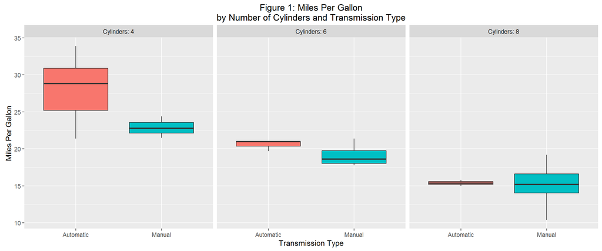

However, the number of cylinders can really be thought of as a factor variable or ‘bin’ variable for engine size. Typically a larger engine will will have more cylinders. And, typically an larger engine (as measured by engine displacement in Cubic Inches), will provide more power to the car.

Figure 2 below shows cars’ MPG as a function of three possible predictors: engine displacement (size), vehicle weight and engine horsepower.

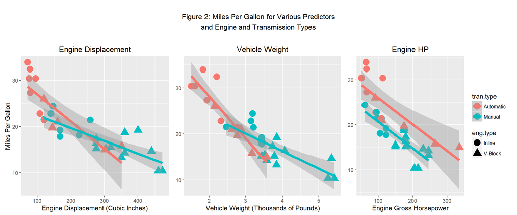

In this study, we want to answer whether a car with an automatic transmission gets different MPG than a car with manual transmission. From Figure 2, a negative correlation between MPG and vehicle weight (center graph) is readily apparent. However, the weight of the vehicle determines the number of horsepower needed to propel the vehicle at a customer acceptable level of performance. The engine size is really more of a proxy for engine horsepower, so for purposes of this study, we’ll use engine horsepower as the predictor variable for the MPG response.

[figure not shown]